# Results: st107d06.sas

LOGISTIC MODEL (3): Backward Elimination Bonus=Basement_Area|Fireplaces|Lot_Shape_2

The LOGISTIC Procedure

| Model Information |  |  |
| --- | --- | --- |
| Data Set | STAT1.AMESHOUSING3 |  |
| Response Variable | Bonus | Sale Price > $175,000 |
| Number of Response Levels | 2 |  |
| Model | binary logit |  |
| Optimization Technique | Fisher's scoring |  |

| Number of Observations Read | 300 |
| --- | --- |
| Number of Observations Used | 299 |

| Response Profile Ordered Value | Response Profile Bonus | Response Profile Total Frequency |
| --- | --- | --- |
| 1 | 0 | 255 |
| 2 | 1 | 44 |

Probability modeled is Bonus='1'.

Note:1 observation was deleted due to missing values for the response or explanatory variables.

Backward Elimination Procedure

| Class Level Information Class | Class Level Information Value | Class Level Information Design Variables | Class Level Information Design Variables |
| --- | --- | --- | --- |
| Fireplaces | 0 | 0 | 0 |
|  | 1 | 1 | 0 |
|  | 2 | 0 | 1 |
| Lot_Shape_2 | Irregular | 1 |  |
|  | Regular | 0 |  |

Step 0. The following effects were entered:

Intercept Basement_Area Fireplaces Basement_*Fireplaces Lot_Shape_2 Basement_*Lot_Shape_ Fireplace*Lot_Shape_

| Model Convergence Status |
| --- |
| Convergence criterion (GCONV=1E-8) satisfied. |

| Model Fit Statistics Criterion | Model Fit Statistics Intercept Only | Model Fit Statistics Intercept and Covariates |
| --- | --- | --- |
| AIC | 251.812 | 141.737 |
| SC | 255.513 | 178.741 |
| -2 Log L | 249.812 | 121.737 |

| Testing Global Null Hypothesis: BETA=0 Test | Testing Global Null Hypothesis: BETA=0 Chi-Square | Testing Global Null Hypothesis: BETA=0 DF | Testing Global Null Hypothesis: BETA=0 Pr > ChiSq |
| --- | --- | --- | --- |
| Likelihood Ratio | 128.0756 | 9 | <.0001 |
| Score | 109.4005 | 9 | <.0001 |
| Wald | 40.8304 | 9 | <.0001 |

Step 1. Effect Fireplace*Lot_Shape_ is removed:

| Model Convergence Status |
| --- |
| Convergence criterion (GCONV=1E-8) satisfied. |

| Model Fit Statistics Criterion | Model Fit Statistics Intercept Only | Model Fit Statistics Intercept and Covariates |
| --- | --- | --- |
| AIC | 251.812 | 141.166 |
| SC | 255.513 | 170.769 |
| -2 Log L | 249.812 | 125.166 |

| Testing Global Null Hypothesis: BETA=0 Test | Testing Global Null Hypothesis: BETA=0 Chi-Square | Testing Global Null Hypothesis: BETA=0 DF | Testing Global Null Hypothesis: BETA=0 Pr > ChiSq |
| --- | --- | --- | --- |
| Likelihood Ratio | 124.6462 | 7 | <.0001 |
| Score | 106.9810 | 7 | <.0001 |
| Wald | 42.3266 | 7 | <.0001 |

| Residual Chi-Square Test Chi-Square | Residual Chi-Square Test DF | Residual Chi-Square Test Pr > ChiSq |
| --- | --- | --- |
| 3.4592 | 2 | 0.1774 |

Step 2. Effect Basement_*Fireplaces is removed:

| Model Convergence Status |
| --- |
| Convergence criterion (GCONV=1E-8) satisfied. |

| Model Fit Statistics Criterion | Model Fit Statistics Intercept Only | Model Fit Statistics Intercept and Covariates |
| --- | --- | --- |
| AIC | 251.812 | 138.872 |
| SC | 255.513 | 161.074 |
| -2 Log L | 249.812 | 126.872 |

| Testing Global Null Hypothesis: BETA=0 Test | Testing Global Null Hypothesis: BETA=0 Chi-Square | Testing Global Null Hypothesis: BETA=0 DF | Testing Global Null Hypothesis: BETA=0 Pr > ChiSq |
| --- | --- | --- | --- |
| Likelihood Ratio | 122.9405 | 5 | <.0001 |
| Score | 102.6370 | 5 | <.0001 |
| Wald | 42.9826 | 5 | <.0001 |

| Residual Chi-Square Test Chi-Square | Residual Chi-Square Test DF | Residual Chi-Square Test Pr > ChiSq |
| --- | --- | --- |
| 5.5364 | 4 | 0.2365 |

Note:No (additional) effects met the 0.1 significance level for removal from the model.

| Summary of Backward Elimination Step | Summary of Backward Elimination Effect Removed | Summary of Backward Elimination DF | Summary of Backward Elimination Number In | Summary of Backward Elimination Wald Chi-Square | Summary of Backward Elimination Pr > ChiSq | Summary of Backward Elimination Variable Label |
| --- | --- | --- | --- | --- | --- | --- |
| 1 | Fireplace*Lot_Shape_ | 2 | 5 | 3.2305 | 0.1988 |  |
| 2 | Basement_*Fireplaces | 2 | 4 | 1.7237 | 0.4224 |  |

| Joint Tests Effect | Joint Tests DF | Joint Tests Wald Chi-Square | Joint Tests Pr > ChiSq |
| --- | --- | --- | --- |
| Basement_Area | 1 | 18.2896 | <.0001 |
| Fireplaces | 2 | 4.7171 | 0.0946 |
| Lot_Shape_2 | 1 | 5.0247 | 0.0250 |
| Basement_*Lot_Shape_ | 1 | 3.1127 | 0.0777 |

Note:Under full-rank parameterizations, Type 3 effect tests are replaced by joint tests. The joint test for an effect is a test that all the parameters associated with that effect are zero. Such joint tests might not be equivalent to Type 3 effect tests under GLM parameterization.

| Analysis of Maximum Likelihood Estimates Parameter | Analysis of Maximum Likelihood Estimates | Analysis of Maximum Likelihood Estimates DF | Analysis of Maximum Likelihood Estimates Estimate | Analysis of Maximum Likelihood Estimates Standard Error | Analysis of Maximum Likelihood Estimates Wald Chi-Square | Analysis of Maximum Likelihood Estimates Pr > ChiSq |
| --- | --- | --- | --- | --- | --- | --- |
| Intercept |  | 1 | -15.3017 | 3.2407 | 22.2952 | <.0001 |
| Basement_Area |  | 1 | 0.0109 | 0.00254 | 18.2896 | <.0001 |
| Fireplaces | 1 | 1 | 0.7671 | 0.4687 | 2.6781 | 0.1017 |
| Fireplaces | 2 | 1 | -0.9405 | 0.9503 | 0.9795 | 0.3223 |
| Lot_Shape_2 | Irregular | 1 | 8.0362 | 3.5850 | 5.0247 | 0.0250 |
| Basement_*Lot_Shape_ | Irregular | 1 | -0.00503 | 0.00285 | 3.1127 | 0.0777 |

| Association of Predicted Probabilities and Observed Responses |  |  |  |
| --- | --- | --- | --- |
| Percent Concordant | 93.8 | Somers' D | 0.876 |
| Percent Discordant | 6.2 | Gamma | 0.876 |
| Percent Tied | 0.1 | Tau-a | 0.221 |
| Pairs | 11220 | c | 0.938 |

| Odds Ratio Estimates and Profile-Likelihood Confidence Intervals Effect | Odds Ratio Estimates and Profile-Likelihood Confidence Intervals Unit | Odds Ratio Estimates and Profile-Likelihood Confidence Intervals Estimate | Odds Ratio Estimates and Profile-Likelihood Confidence Intervals 95% Confidence Limits | Odds Ratio Estimates and Profile-Likelihood Confidence Intervals 95% Confidence Limits |
| --- | --- | --- | --- | --- |
| Fireplaces 1 vs 0 | 1.0000 | 2.153 | 0.865 | 5.500 |
| Fireplaces 2 vs 0 | 1.0000 | 0.390 | 0.047 | 2.251 |

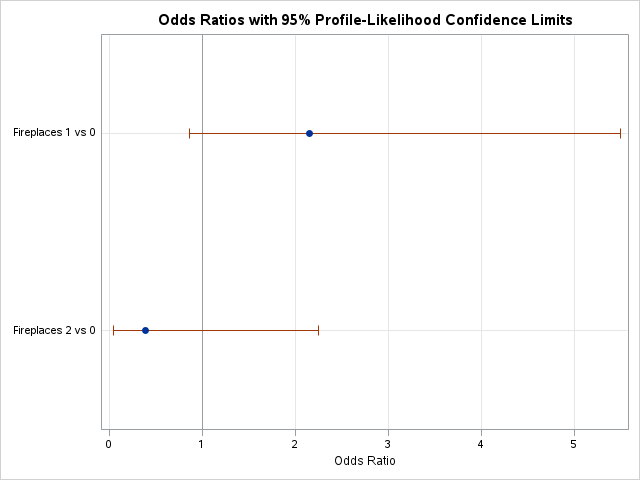

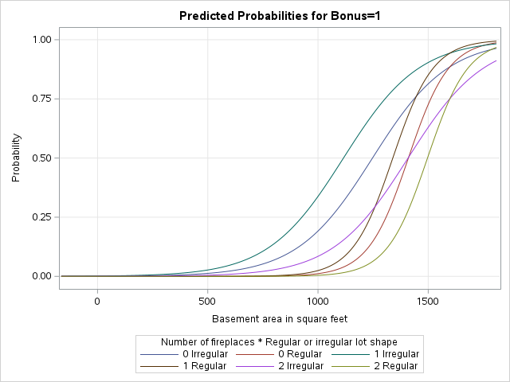

LOGISTIC MODEL (3.1): Bonus=Basement_Area|Lot_Shape_2 Fireplaces

The LOGISTIC Procedure

| Model Information |  |  |
| --- | --- | --- |
| Data Set | STAT1.AMESHOUSING3 |  |
| Response Variable | Bonus | Sale Price > $175,000 |
| Number of Response Levels | 2 |  |
| Model | binary logit |  |
| Optimization Technique | Fisher's scoring |  |

| Number of Observations Read | 300 |
| --- | --- |
| Number of Observations Used | 299 |

| Response Profile Ordered Value | Response Profile Bonus | Response Profile Total Frequency |
| --- | --- | --- |
| 1 | 0 | 255 |
| 2 | 1 | 44 |

Probability modeled is Bonus='1'.

Note:1 observation was deleted due to missing values for the response or explanatory variables.

| Class Level Information Class | Class Level Information Value | Class Level Information Design Variables | Class Level Information Design Variables |
| --- | --- | --- | --- |
| Fireplaces | 0 | 0 | 0 |
|  | 1 | 1 | 0 |
|  | 2 | 0 | 1 |
| Lot_Shape_2 | Irregular | 1 |  |
|  | Regular | 0 |  |

| Model Convergence Status |
| --- |
| Convergence criterion (GCONV=1E-8) satisfied. |

| Model Fit Statistics Criterion | Model Fit Statistics Intercept Only | Model Fit Statistics Intercept and Covariates |
| --- | --- | --- |
| AIC | 251.812 | 138.872 |
| SC | 255.513 | 161.074 |
| -2 Log L | 249.812 | 126.872 |

| Testing Global Null Hypothesis: BETA=0 Test | Testing Global Null Hypothesis: BETA=0 Chi-Square | Testing Global Null Hypothesis: BETA=0 DF | Testing Global Null Hypothesis: BETA=0 Pr > ChiSq |
| --- | --- | --- | --- |
| Likelihood Ratio | 122.9405 | 5 | <.0001 |
| Score | 102.6370 | 5 | <.0001 |
| Wald | 42.9826 | 5 | <.0001 |

| Joint Tests Effect | Joint Tests DF | Joint Tests Wald Chi-Square | Joint Tests Pr > ChiSq |
| --- | --- | --- | --- |
| Basement_Area | 1 | 18.2896 | <.0001 |
| Lot_Shape_2 | 1 | 5.0247 | 0.0250 |
| Basement_*Lot_Shape_ | 1 | 3.1127 | 0.0777 |
| Fireplaces | 2 | 4.7171 | 0.0946 |

Note:Under full-rank parameterizations, Type 3 effect tests are replaced by joint tests. The joint test for an effect is a test that all the parameters associated with that effect are zero. Such joint tests might not be equivalent to Type 3 effect tests under GLM parameterization.

| Analysis of Maximum Likelihood Estimates Parameter | Analysis of Maximum Likelihood Estimates | Analysis of Maximum Likelihood Estimates DF | Analysis of Maximum Likelihood Estimates Estimate | Analysis of Maximum Likelihood Estimates Standard Error | Analysis of Maximum Likelihood Estimates Wald Chi-Square | Analysis of Maximum Likelihood Estimates Pr > ChiSq |
| --- | --- | --- | --- | --- | --- | --- |
| Intercept |  | 1 | -15.3017 | 3.2407 | 22.2952 | <.0001 |
| Basement_Area |  | 1 | 0.0109 | 0.00254 | 18.2896 | <.0001 |
| Lot_Shape_2 | Irregular | 1 | 8.0362 | 3.5850 | 5.0247 | 0.0250 |
| Basement_*Lot_Shape_ | Irregular | 1 | -0.00503 | 0.00285 | 3.1127 | 0.0777 |
| Fireplaces | 1 | 1 | 0.7671 | 0.4687 | 2.6781 | 0.1017 |
| Fireplaces | 2 | 1 | -0.9405 | 0.9503 | 0.9795 | 0.3223 |

| Odds Ratio Estimates Effect | Odds Ratio Estimates Point Estimate | Odds Ratio Estimates 95% Wald Confidence Limits | Odds Ratio Estimates 95% Wald Confidence Limits |
| --- | --- | --- | --- |
| Fireplaces 1 vs 0 | 2.153 | 0.859 | 5.396 |
| Fireplaces 2 vs 0 | 0.390 | 0.061 | 2.514 |

[figure not shown]

| Association of Predicted Probabilities and Observed Responses |  |  |  |
| --- | --- | --- | --- |
| Percent Concordant | 93.8 | Somers' D | 0.876 |
| Percent Discordant | 6.2 | Gamma | 0.876 |
| Percent Tied | 0.1 | Tau-a | 0.221 |
| Pairs | 11220 | c | 0.938 |

| Odds Ratio Estimates and Profile-Likelihood Confidence Intervals Odds Ratio | Odds Ratio Estimates and Profile-Likelihood Confidence Intervals Estimate | Odds Ratio Estimates and Profile-Likelihood Confidence Intervals 95% Confidence Limits | Odds Ratio Estimates and Profile-Likelihood Confidence Intervals 95% Confidence Limits |
| --- | --- | --- | --- |
| Basement_Area units=100 at Lot_Shape_2=Irregular | 1.791 | 1.421 | 2.396 |
| Basement_Area units=100 at Lot_Shape_2=Regular | 2.960 | 1.932 | 5.315 |
| Lot_Shape_2 Irregular vs Regular at Basement_Area=1000 | 20.278 | 4.623 | 146.987 |
| Lot_Shape_2 Irregular vs Regular at Basement_Area=1500 | 1.643 | 0.283 | 9.145 |

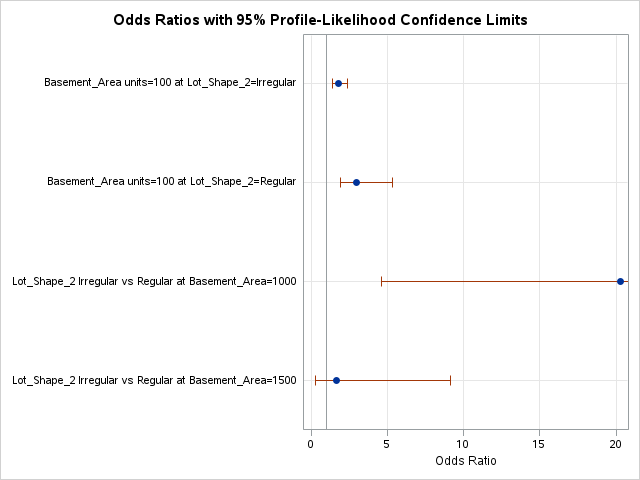